# hbn_exclusion_demo

2025-03-24

## Minimal exclusion criteria

Across recruitment sites, inclusion criteria consisted of being in the required age range and able to provide informed consent (parents) and assent (child). Exclusions were minimal and were limited to lack of English language proficiency in the children, the presence of severe sensory, intellectual, medical or neurological issues that would impact the validity of collected data or the child’s ability to comply with the protocol, and contraindications to MRI scanning ([Garavan et al., 2018](https://www.sciencedirect.com/science/article/pii/S1878929317301809)). Parents must be fluent in either English or Spanish.

### 1) dMRI QC

```r
allnum1 <- nrow(basic_demo)
QCtable <- read.csv(paste0(demo_path, "/participants.csv"))
basic_demo$subID <- paste0("sub-", basic_demo$subID)
basic_demo <- merge(basic_demo, QCtable, by.x="subID", by.y="subject_id")
basic_demo$age.y <- basic_demo$sex.y <- NULL
basic_demo <- dplyr::rename(basic_demo, all_of(c(age="age.x", sex="sex.x")))

allnum2 <- nrow(basic_demo)
print(paste((allnum1-allnum2), "participants were excluded due to unsuccessful qsiprep or missing files as reported in Richie-Halford et al., 2022.", allnum2, "left."))
```

```
## [1] "2751 participants were excluded due to unsuccessful qsiprep or missing files as reported in Richie-Halford et al., 2022. 2117 left."
```

```r
basic_demo <- basic_demo %>% filter(dl_qc_score > 0.05, scan_site_id!="SI", (site_variant %in% c("CBIC_64dir_Most_Common", "CBIC_64dir_Obliquity", "CBIC_ABCD64dir_Most_Common", "CBIC_ABCD64dir_MultibandAccelerationFactor", "CUNY_64dir_Most_Common", "CUNY_64dir_Obliquity", "RU_64dir_Most_Common", "RU_64dir_Obliquity")))
allnum3 <- nrow(basic_demo)
print(paste((allnum2-allnum3), "participants were excluded due to low QC & 1.5T MRI.", allnum3, "left."))
```

```
## [1] "664 participants were excluded due to low QC & 1.5T MRI. 1453 left."
```

```r
QCjson <- rjson::fromJSON(file=paste0(demo_path, "/dwiqc.json"))
QCjson <- QCjson$subjects
QCtable <- data.frame(matrix(NA, 2135, 2))
names(QCtable) <- c("subID", "mean_fd")

for (i in 1:2135){
  QCtable$subID[i] <- QCjson[[i]]$participant_id
  QCtable$mean_fd[i] <- QCjson[[i]]$mean_fd
}

QCtable.exclude <- QCtable %>% filter(mean_fd > mean(mean_fd)+3*sd(mean_fd) | mean_fd < mean(mean_fd)-3*sd(mean_fd))
basic_demo <- basic_demo %>% filter(! subID %in% QCtable.exclude$subID) %>% left_join(QCtable, by="subID")
allnum4 <- nrow(basic_demo)
print(paste((allnum3-allnum4), "participants were excluded due to excessive head motion.", allnum4, "left."))
```

```
## [1] "0 participants were excluded due to excessive head motion. 1453 left."
```

### 2) Language

Because participants were enrolled with criteria of being fluent in English. So no more exclusion for language issues in this study.

### 3) Traumatic brain injury history

Have been knocked out TBI_01 = 1 A knocked out happened. TBI_05_effect / TBI_06_effect / TBI_07_effect / TBI_08_effect / TBI_09_effect / TBI_10_effect == 2

```r
TBI <- read.csv(paste0(demo_path, "/TBI.csv"))
TBI.exclude <- TBI %>% filter(TBI.TBI_01 == 1 & (TBI.TBI_05_effect==2 | TBI.TBI_06_effect==2 | TBI.TBI_07_effect==2 |
                                           TBI.TBI_08_effect==2 | TBI.TBI_09_effect==2 | TBI.TBI_10_effect==2))

basic_demo <- basic_demo %>% filter(! subID %in% paste0("sub-", TBI.exclude$TBI.EID))
allnum5 <- nrow(basic_demo)
print(paste((allnum4-allnum5), "participants were excluded due to mild or more severe TBI.", allnum5, "left."))
```

```
## [1] "7 participants were excluded due to mild or more severe TBI. 1446 left."
```

### 4) Sensory issues

The exclusion criteria of HBN including hearing or visual impairment that prevents participation in study-released tasks. No more exclusion for sensory issues in this study.

### 5) Intellectual disability

```r
WISC <- read.csv(paste0(demo_path, "/WISC.csv"))
WISC_remote <- read.csv(paste0(demo_path, "/WISC_remote.csv"))
WAIS <- read.csv(paste0(demo_path, "/WAIS.csv"))
WAIS_Abb <- read.csv(paste0(demo_path, "/WAIS_Abb.csv"))

WISC.exclude <- WISC %>% filter(WISC.WISC_FSIQ < 70)
WISC_remote.exclude <- WISC_remote %>% filter(WISC_Remote.WISC_NMFSIQ < 70)
WAIS.excludde <- WAIS %>% filter(WAIS.WAIS_FSIQ_COMP < 70)

basic_demo <- basic_demo %>% filter(! subID %in% paste0("sub-", c(WISC.exclude$WISC.EID, WISC_remote.exclude$WISC_Remote.EID, WAIS.excludde$WAIS.EID)))
allnum6 <- nrow(basic_demo)
print(paste((allnum5-allnum6), "participants were excluded due to intellectual disability.", allnum6, "left."))
```

```
## [1] "31 participants were excluded due to intellectual disability. 1415 left."
```

### 6) Major medical or neurological conditions

The exclusion criteria of HBN including serious neurological disorders; acute encephalopathy caused by an injury to the brain or disease; known neurodegenerative disorder; recent diagnosis of Schizophrenia, Schizoaffective Disorder, or Bipolar Disorder; manic or psychotic episode within the past 6 months without current, ongoing treatment. In addition, detailed physical medical conditions were not provided in HBN, no more exclusion was performed for major medical or neurological conditions in this study.

### 7) Age & Sex

```r
basic_demo$sex <- as.factor(basic_demo$sex)
summary(basic_demo[, c("age", "sex")])
```

```
##       age         sex
##  Min.   : 5.036   0:916
##  1st Qu.: 8.090   1:499
##  Median :10.074
##  Mean   :10.759
##  3rd Qu.:12.951
##  Max.   :21.899
```

```r
basic_demo <- basic_demo %>% drop_na(c("age", "sex"))
allnum7 <- nrow(basic_demo)
print(paste((allnum6-allnum7), "participants were excluded due to missing age or sex information.", allnum7, "left."))
```

```
## [1] "0 participants were excluded due to missing age or sex information. 1415 left."
```

```r
write.csv(basic_demo, paste0(outputpath, "/HBN_demolist.csv"), row.names = F)
```

### 8) diagnosis

```r
Consensus <- read.csv(paste0(demo_path, "/Diagnosis_ClinicianConsensus.csv"))
names(Consensus) <- gsub("Diagnosis_ClinicianConsensus.","", names(Consensus))
diagnosisvar <- paste0("DX_", sprintf("%02d", 1:10))
# ADHD
ADHDlabel <- Consensus$DX_01[c(grep("ADHD", Consensus$DX_01),grep("Attention", Consensus$DX_01))]
ADHDlabel <- unique(ADHDlabel)
print(ADHDlabel)
```

```
## [1] "ADHD-Combined Type"
## [2] "ADHD-Inattentive Type"
## [3] "ADHD-Hyperactive/Impulsive Type"
## [4] "Other Specified Attention-Deficit/Hyperactivity Disorder"
## [5] "Unspecified Attention-Deficit/Hyperactivity Disorder"
```

```r
Consensus <- Consensus %>% mutate(
  if_ADHD = if_any(
    any_of(diagnosisvar),
    ~ str_detect(., regex(paste(ADHDlabel, collapse = "|"), ignore_case = TRUE))
  ) %>% as.integer()
)
table(Consensus$if_ADHD)
```

```
##
##    0    1
## 2107 2660
```

```r
# TD
TDlabel <- "No Diagnosis Given"
Consensus <- Consensus %>% mutate(
  if_TD = if_any(
    any_of(diagnosisvar),
    ~ . ==TDlabel)
)
table(Consensus$if_TD)
```

```
##
## FALSE  TRUE
##  4394   373
```

```r
## Commorbidity: schizophrenia, major depressive disorder present, substance abuse, ASD
Commlabel <- Consensus$DX_01[c(grep("Schizophrenia", Consensus$DX_01),grep("Major Depressive Disorder", Consensus$DX_01), grep("Autism", Consensus$DX_01), grep("Alcohol", Consensus$DX_01))]
Commlabel <- unique(Commlabel)
print(Commlabel)
```

```
## [1] "Other Specified Schizophrenia Spectrum and Other Psychotic Disorder"
## [2] "Schizophrenia"
## [3] "Major Depressive Disorder"
## [4] "Autism Spectrum Disorder"
## [5] "Alcohol Use Disorder"
```

```r
Consensus <- Consensus %>% mutate(
  if_Commorbidity = if_any(
    any_of(diagnosisvar),
    ~ . %in% Commlabel)
)
table(Consensus$if_Commorbidity)
```

```
##
## FALSE  TRUE
##  3837   930
```

```r
# We only keep subjects diagnosed as ADHD or TD and not diagnosed as any disease in commorbidity list.
Consensus.keep <- Consensus %>% filter(
  (if_ADHD == 1 & if_Commorbidity==F) | if_TD==T
)
Consensus.keep$subID <- paste0("sub-", gsub(",assessment", "", Consensus.keep$Identifiers))

basic_demo <- basic_demo %>% left_join(select(Consensus.keep, subID, if_ADHD, if_TD), by="subID")
basic_demo2 <- basic_demo %>% filter(if_ADHD == 1 | if_TD==T)

allnum8 <- nrow(basic_demo2)
print(paste((allnum7-allnum8), "participants were excluded due to not match the diagnosis.", allnum8, "containing ", table(basic_demo2$if_ADHD)[2], " ADHD children left."))
```

```
## [1] "663 participants were excluded due to not match the diagnosis. 752 containing  648  ADHD children left."
```

### 8) qsirecon success

```r
## subjects with qsiprep finished.
subjectsfinished <- readMat(paste0(demo_path, "/sublist_finished_qsi.mat"))
subjectsfinished <- subjectsfinished$sublist.finished
subjectsfinished.vec <- unlist(lapply(subjectsfinished, unlist))

subjectsunfinished <- readMat(paste0(demo_path, "/sublist_unfinished_qsi.mat"))
subjectsunfinished <- subjectsunfinished$sublist.unfinished
subjectsunfinished.vec <- unlist(lapply(subjectsunfinished, unlist))
basic_demo2$qsiprep_finished <- ((!(basic_demo2$subID %in% subjectsunfinished.vec)) & (basic_demo2$subID %in% subjectsfinished.vec))
summary(basic_demo2$qsiprep_finished)
```

```
##    Mode   FALSE    TRUE
## logical      20     732
```

```r
write.csv(basic_demo2, paste0(result_path, "/basic_demo_screenqsirecon.csv"), row.names = F)
basic_demo2 <- basic_demo2 %>% filter(qsiprep_finished==T)
basic_demo2 <- basic_demo2 %>% filter(subID != "sub-NDARPD568LHV")
allnum9 <- nrow(basic_demo2)
print(paste(sum(basic_demo2$qsiprep_finished), "SC matrices were successfully reconstructed.", (allnum8-allnum9), "participants failed."))
```

```
## [1] "732 SC matrices were successfully reconstructed. 20 participants failed."
```

### Merge handedness

```r
EHQ <- read.csv(paste0(demo_path, "/EHQ.csv"))
EHQ <- EHQ %>% mutate(
  handedness=case_when(
    EHQ.EHQ_Total < -60 ~ "left",
    EHQ.EHQ_Total >= -60 & EHQ.EHQ_Total <= 60  ~ "mixed",
    EHQ.EHQ_Total > 60 ~ "right"
  )
)
EHQ$EHQ.EID <- paste0("sub-", EHQ$EHQ.EID)
basic_demo2 <- basic_demo2 %>% left_join(select(EHQ, c("EHQ.EID", "handedness")), join_by(subID==EHQ.EID))
basic_demo2$handedness <- as.factor(basic_demo2$handedness)
summary(basic_demo2$handedness)
```

```
##  left mixed right  NA's
##    39   200   492     1
```

### Merge race

```r
PreInt_Demos_Fam <- read.csv(paste0(demo_path, "/PreInt_Demos_Fam.csv"))
PreInt_Demos_Fam <- PreInt_Demos_Fam %>% mutate(
  race_ethnicity=case_when(
    PreInt_Demos_Fam.Child_Ethnicity==1 ~ "Hispanic",
    PreInt_Demos_Fam.Child_Ethnicity!=1 & PreInt_Demos_Fam.Child_Race==0 ~ "White",
    PreInt_Demos_Fam.Child_Ethnicity!=1 & PreInt_Demos_Fam.Child_Race==1 ~ "Black",
    PreInt_Demos_Fam.Child_Ethnicity!=1 & PreInt_Demos_Fam.Child_Race==3 ~ "Asian",
    PreInt_Demos_Fam.Child_Ethnicity!=1 & PreInt_Demos_Fam.Child_Race>3~ "Other"
  )
)
PreInt_Demos_Fam$PreInt_Demos_Fam.EID <- paste0("sub-", PreInt_Demos_Fam$PreInt_Demos_Fam.EID)
basic_demo2 <- basic_demo2 %>% left_join(select(PreInt_Demos_Fam, c("PreInt_Demos_Fam.EID", "race_ethnicity")), join_by(subID==PreInt_Demos_Fam.EID))
basic_demo2$race_ethnicity <- as.factor(basic_demo2$race_ethnicity)
summary(basic_demo2$race_ethnicity)
```

```
##    Asian    Black Hispanic    Other    White     NA's
##       16       69      177       97      349       24
```

### Merge cognition

```r
## basic_demo data clean
cognitiondf <- read.csv(paste0(demo_path, "/basic_demo.csv"))
cognitiondf <- cognitiondf %>% select(c("Identifiers", "assessment.Basic_Demos.Age", "assessment.Basic_Demos.Sex", "assessment.Basic_Demos.Study_Site")) %>% drop_na()
names(cognitiondf) <- c("subID", "age", "sex", "site")
cognitiondf <- cognitiondf %>% filter(! subID %in% TBI.exclude$TBI.EID)
cognitiondf <- cognitiondf %>% filter(! subID %in% c(WISC.exclude$WISC.EID, WISC_remote.exclude$WISC_Remote.EID, WAIS.excludde$WAIS.EID))
cognitiondf$subID <- paste0("sub-", cognitiondf$subID)

NIH_final <- read.csv(paste0(demo_path, "/NIH_final.csv"))
NIH_score <- read.csv(paste0(demo_path, "/NIH_score.csv"))
NIH <- read.csv(paste0(demo_path, "/NIH.csv"))

NIH_final$NIH_final.EID <- paste0("sub-", NIH_final$NIH_final.EID)
NIH$NIH.EID <- paste0("sub-", NIH$NIH.EID)
NIH_score$NIH_Scores.EID <- paste0("sub-", NIH_score$NIH_Scores.EID)
# NIH_final
cognitiondf <- cognitiondf %>% left_join(select(NIH_final, c(ends_with("_Uncorr_Stnd"), ends_with("_Age_Corr_Stnd"), "NIH_final.EID")), join_by(subID==NIH_final.EID))
# NIH_score
cognitiondf <- cognitiondf %>% left_join(select(NIH_score, c("NIH_Scores.NIH7_Comp", "NIH_Scores.EID")), join_by(subID==NIH_Scores.EID))
# NIH
cognitiondf <- cognitiondf %>% left_join(select(NIH, c(ends_with("_Uncorr_Stnd"), ends_with("_Age_Corr_Stnd"), "NIH.EID")), join_by(subID==NIH.EID))

#summary(basic_demo[,c("NIH.NIH_Picture_Seq_Uncorr_Stnd", "NIH.NIH_List_Sort_Uncorr_Stnd", "NIH.NIH_Processing_Uncorr_Stnd", "NIH.NIH_Flanker_Uncorr_Stnd", "NIH.NIH_Card_Sort_Uncorr_Stnd")])
#summary(basic_demo[,c("NIH_final.NIH_Picture_Seq_Uncorr_Stnd", "NIH_final.NIH_List_Sort_Uncorr_Stnd", "NIH.NIH_Processing_Uncorr_Stnd", "NIH.NIH_Flanker_Uncorr_Stnd", "NIH_final.NIH_Card_Sort_Uncorr_Stnd")])

cognitiondf <- cognitiondf %>%
  mutate(NIH_final.NIH_Picture_Seq_Uncorr_Stnd = if_else(is.na(NIH_final.NIH_Picture_Seq_Uncorr_Stnd), NIH.NIH_Picture_Seq_Uncorr_Stnd, NIH_final.NIH_Picture_Seq_Uncorr_Stnd),
         NIH_final.NIH_List_Sort_Uncorr_Stnd = if_else(is.na(NIH_final.NIH_List_Sort_Uncorr_Stnd), NIH.NIH_List_Sort_Uncorr_Stnd, NIH_final.NIH_List_Sort_Uncorr_Stnd),
         NIH_final.NIH_Processing_Uncorr_Stnd = if_else(is.na(NIH_final.NIH_Processing_Uncorr_Stnd), NIH.NIH_Processing_Uncorr_Stnd, NIH_final.NIH_Processing_Uncorr_Stnd),
         NIH_final.NIH_Flanker_Uncorr_Stnd = if_else(is.na(NIH_final.NIH_Flanker_Uncorr_Stnd), NIH.NIH_Flanker_Uncorr_Stnd, NIH_final.NIH_Flanker_Uncorr_Stnd),
         NIH_final.NIH_Card_Sort_Uncorr_Stnd = if_else(is.na(NIH_final.NIH_Card_Sort_Uncorr_Stnd), NIH.NIH_Card_Sort_Uncorr_Stnd, NIH_final.NIH_Card_Sort_Uncorr_Stnd)
         )

#summary(basic_demo[,c("NIH_final.NIH_Picture_Seq_Uncorr_Stnd", "NIH_final.NIH_List_Sort_Uncorr_Stnd", "NIH.NIH_Processing_Uncorr_Stnd", "NIH.NIH_Flanker_Uncorr_Stnd", "NIH_final.NIH_Card_Sort_Uncorr_Stnd")])

# NIH_final.NIH_Card_Sort_Uncorr_Stnd, NIH_final.NIH_Flanker_Uncorr_Stnd, NIH_final.NIH_List_Sort_Uncorr_Stnd,
# NIH_final.NIH_Picture_Seq_Uncorr_Stnd
cogvars <- c("NIH_final.NIH_Card_Sort_Uncorr_Stnd", "NIH_final.NIH_Flanker_Uncorr_Stnd", "NIH_final.NIH_List_Sort_Uncorr_Stnd",
             "NIH_final.NIH_Processing_Uncorr_Stnd")
Behavior_cog <- cognitiondf %>% select(c(cogvars, "subID")) %>% drop_na()
EFPCA <- prcomp(Behavior_cog[,1:4], scale. = TRUE)
summary(EFPCA)
```

```
## Importance of components:
##                          PC1    PC2     PC3     PC4
## Standard deviation     1.672 0.6803 0.62049 0.59678
## Proportion of Variance 0.699 0.1157 0.09625 0.08904
## Cumulative Proportion  0.699 0.8147 0.91096 1.00000
```

```r
# Importance of components:
#                           PC1    PC2     PC3     PC4
# Standard deviation     1.6720 0.6721 0.62788 0.59856
# Proportion of Variance 0.6989 0.1129 0.09856 0.08957
# Cumulative Proportion  0.6989 0.8119 0.91043 1.00000

Behavior_cog$EFPCA <- -EFPCA$x[,1]
basic_demo2 <- basic_demo2 %>% left_join(select(Behavior_cog, c("EFPCA", "subID")), by="subID")
```

### Merge SES

```r
FSQ <- read.csv(paste0(demo_path, "/FSQ.csv"))
FSQ$totalincome <- dplyr::recode(FSQ$FSQ.FSQ_04, `0` = 5000,
  `1` = 15000, `2` = 25000, `3` = 35000, `4` = 45000, `5` = 55000, `6` = 65000, `7` = 75000, `8` = 85000, `9` = 95000, `10` = 125000, `11` = 175000)
reference_data <- data.frame(familysize = rep(c(1:12),7),
                             povertyline = c(11880,16020,20160,24300,28440,32580,36730,40890,
                                             seq(from=45050, to=(45050+4160*3), by=4160), 12140,16460,20780,25100,29420,33740,38060,42380, 46700,51020, 55340,  59660, 12060,16240,20420,24600,28780,32960,37140,41320, 45500,  49680,  53860,  58040,12490,    16910,  21330,  25750,  30170,  34590,  39010,  43430,  47850,  52270,  56690,  61110,
                                             seq(from=12760, to=(12760+4480*11), by=4480),
                                             seq(from=12880, to=(12880+4540*11), by=4540),
                                             seq(from=13590, to=(13590+4720*11), by=4720)),
                             Year = c(rep(2016,12),rep(2018,12), rep(2017,12), rep(2019,12),rep(2020,12),rep(2021,12),rep(2022,12)))

FSQ <- merge(FSQ, reference_data,
                          by.x = c("FSQ.Year", "FSQ.FSQ_08"),
                          by.y = c("Year", "familysize"),
                          all.x = TRUE)
FSQ$income.adj<-FSQ$totalincome / FSQ$povertyline
summary(FSQ$income.adj)
```

```
##    Min. 1st Qu.  Median    Mean 3rd Qu.    Max.    NA's
##  0.1099  2.6611  4.8544  4.5595  6.6038 14.5108     590
```

```r
FSQ$FSQ.EID <- paste0("sub-", FSQ$FSQ.EID)
basic_demo2 <- basic_demo2 %>% left_join(select(FSQ, c("FSQ.EID", "income.adj")), join_by(subID==FSQ.EID))
```

### Merge CBCL, p-factor

P factors provided by HBN-EEG ([Seyed Yahya Shirazi et al., 2024](https://www.biorxiv.org/content/10.1101/2024.10.03.615261v2)) were used.

```r
pfactortab <- data.frame(subID=rep(NA, 1), GENERAL=rep(NA, 1), ADHD=rep(NA, 1), Internal=rep(NA, 1), External=rep(NA, 1))
for (i in 1:9){
  EEGtab <- read.table(paste0(demo_path, "/participants_EEGr", i, ".tsv"), header = T)
  pfactortabadd <- EEGtab %>% select(participant_id, p_factor, attention, internalizing, externalizing)
  names(pfactortabadd) <- c("subID", "GENERAL", "ADHD", "Internal", "External")
  pfactortab <- rbind(pfactortab, pfactortabadd)
}
pfactortab <- pfactortab[-1,]
basic_demo2 <- basic_demo2 %>% left_join(pfactortab, by="subID")

CBCL <- read.csv(paste0(demo_path, "/CBCL.csv"))
CBCL_Pre <- read.csv(paste0(demo_path, "/CBCL_Pre.csv"))
CBCL$CBCL.EID <- paste0("sub-", CBCL$CBCL.EID)
CBCL_Pre$CBCL_Pre.EID <- paste0("sub-", CBCL_Pre$CBCL_Pre.EID)
CBCL <- CBCL %>% select(CBCL.CBCL_Total, CBCL.CBCL_Total_T, CBCL.EID)
CBCL_Pre <- CBCL_Pre %>% select(CBCL_Pre.CBCLPre_Total, CBCL_Pre.CBCLPre_Total_T, CBCL_Pre.EID)
basic_demo2 <- basic_demo2 %>% left_join(CBCL, join_by(subID==CBCL.EID))
basic_demo2 <- basic_demo2 %>% left_join(CBCL_Pre, join_by(subID==CBCL_Pre.EID))

basic_demo2 <- basic_demo2 %>% mutate(
  CBCL_total = case_when(
    is.na(CBCL.CBCL_Total) ~ CBCL_Pre.CBCLPre_Total,
    .default = CBCL.CBCL_Total
  ),
  CBCL_total_T = case_when(
    is.na(CBCL.CBCL_Total_T) ~ CBCL_Pre.CBCLPre_Total_T,
    .default = CBCL.CBCL_Total_T
  )
)

write.csv(basic_demo2, paste0(result_path, "/basic_demo_merge_screen_MRIQC.csv"), row.names = F)
```

### Plot age distribution

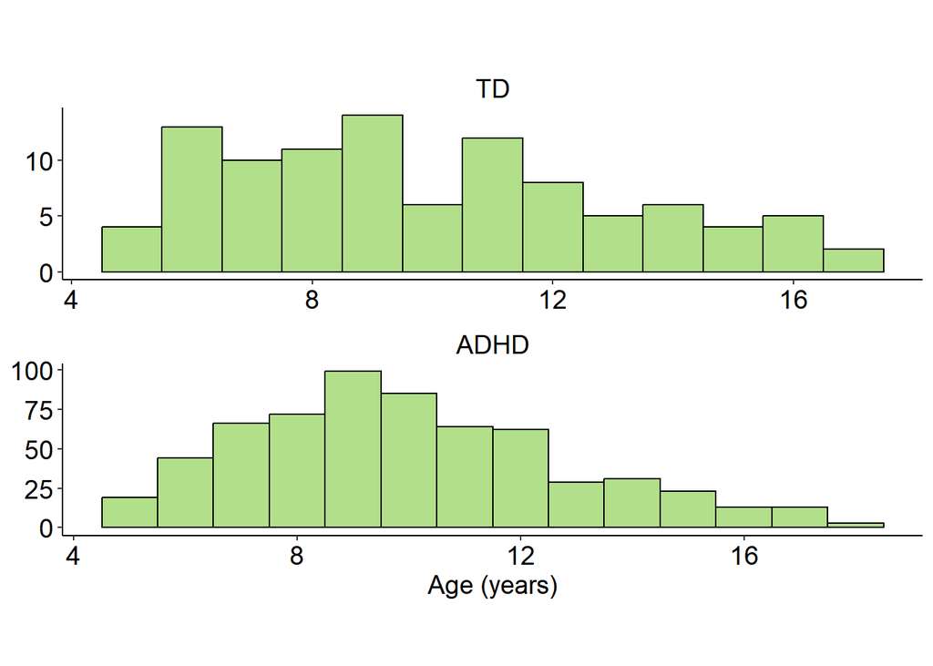

```r
basic_demo2$if_TD <- factor(basic_demo2$if_TD, levels = c(T, F), labels=c("TD", "ADHD"))
basic_demo2 <- basic_demo2 %>% filter(age < 18)
ggplot(data = basic_demo2, aes(age, y = ..count..)) +
  geom_histogram(binwidth = 1, color = "black", fill="#B2DF8A", position = "stack",linewidth=0.5) +
  facet_wrap(~if_TD, ncol = 1, nrow = 2, scales = "free") +
  labs(x = "Age (years)", y = NULL) +
  #scale_x_continuous(limits = c(9, 16), breaks = c(9,10,11,12,13,14,15,16)) +
  #scale_y_continuous(limits = c(0, 50), breaks = c(0,10, 20,30,40, 50)) +
  #geom_hline(aes(yintercept = 10), colour = "red", linetype="dashed")+
  theme_classic()+
  theme(panel.background = element_rect(fill="transparent"),
        plot.background = element_rect(fill = "transparent",colour = NA),aspect.ratio = 0.2,
        plot.title = element_text(color = "black", size = 14, hjust = 0.5),
        strip.text = element_text(size = 14, color = "black"),
        strip.background = element_rect(fill = "transparent",colour = NA),
        axis.title = element_text(color = "black", size = 14),axis.line = element_line(linewidth = 0.4),
        axis.ticks = element_line(linewidth = 0.4),
        axis.text = element_text(color = "black", size = 14),
        legend.text = element_text(color = "black", size = 12),
        legend.title = element_text(color = "black", size = 12))
```

```r
ggsave(paste(FigureFolderHBN, '/Fig1_Age_distribution_count_ABCD_ADHDall.tiff', sep = ''),  width = 20, height = 20, units = "cm")
ggsave(paste(FigureFolderHBN, '/Fig1_Age_distribution_count_ABCD_ADHDall.svg', sep = ''), width = 20, height = 20, units = "cm")

## Description for demographic information
HBN_vars <- c("age", "sex","site", "ehq_total", "if_TD")
HBN_tableone <- CreateTableOne(HBN_vars,strata="if_TD", data = basic_demo2, factorVars=c("sex","site"), test=F)
HBN_tableone <- as.data.frame(print(HBN_tableone))
```

```
##                        Stratified by if_TD
##                         TD            ADHD
##   n                       100           623
##   age (mean (SD))        9.91 (3.20)   9.98 (2.84)
##   sex = 1 (%)              47 (47.0)    188 ( 30.2)
##   site (%)
##      1                     56 (56.0)    288 ( 46.2)
##      3                     34 (34.0)    230 ( 36.9)
##      4                     10 (10.0)    105 ( 16.9)
##   ehq_total (mean (SD)) 61.13 (50.51) 61.82 (50.22)
##   if_TD = ADHD (%)          0 ( 0.0)    623 (100.0)
```

```r
write.csv(HBN_tableone, paste0(FigureFolderHBN, '/MRIdemographic_info.csv'))
```